# Modeling and prediction for movies

## Setup

### Load packages

```r
library(ggplot2)
library(dplyr)
library(statsr)
```

### Load data

```r
 load("C:/Users/JV/OneDrive/Coursera files/Linear Regression and Modeling/_e1fe0c85abec6f73c72d73926884eaca_movies.rdata")
```

## Part 1: Data

The data involved in this project is said to be derived from 651 randomly selected sampled movies produced and released before 2016. Considering that 651 movies is less than 10% of all movies produced and released before 2016 and that the samples were chosen randomly, independence and generalizability is acceptable. However, since the data is from observational methods and that there was no random assignment for control and treatment group, causation can’t be inferred.

## Part 2: Research question

Entertainment has been an intergral part of society, and throughout the years, it has changed and will continue to change with the constant evolution of society. While entertainment is perhaps one of the most important avenues for creative expression and development, one might argue that the value of entertainment stems from the fact that it provides a temporary respite from the rigors of real life. As such, the audience not only can appreciate the talent and the work involved in making one form of entertainment (e.g. movie, TV show, concert), but can also suspend his/her thoughts or concerns in his/her own life while getting immersed on the experience. As a result, entertainment can have some form or degree of emotional effect to its audience. Such an effect can contribute towards how popular or well-received an entertainment event could be.

Movies, in particular, involve a lot of resources and investment. One such resource that involves both the movie makers and the audience is time. Movie makers might consider on whether a great movie has to be short or long. This is important since a shorter movie usually requires lesser resources and expense than a longer one. In the perspective of the audience, a long movie, depending on other factors as well, can be dragging, resulting to a less pleasuarble experience. In the same sense, a shorter one can potentially leave out important scences that prevent audiences from establishing a deeper connection with the movie’s entirety. Therefore, the main question for this project is: “Is there an association between movie popularity (audience_score) and movie length (runtime)?”

## Part 3: Exploratory data analysis

From the data taken from the IMDB and Rotten Tomatoes, only imdb_rating, critics_score, and audience_score variables can be used to represent the popularity of movies. Among the three, the audience_score is chosen to be the response variable since it is derived mainly from the input of the audience and not from professional critics who may have more skill and knowledge in evaluating movies. To answer the research question, the variable runtime will be the predictor variable.After going through the rest of the variables, the following variables can have potential effects on the response variables (imdb_rating, critics_score, and audience_score), and therefore considered as explanatory or predictor variables: genre, runtime, mpaa_rating, imdb_num_votes, critics_rating, best_pic_nom, best_pic_win, best_actor_win, best_actress_win, and best_dir_win. While the variable top200_box may seem relevant, it is more likely the result of the movie’s popularity rather than a contributing factor, so therefore it was not considered as one of the explanatory or predictor variables.

Basing on the above explanation, a new dataframe was formed with the needed variables.

```r
movies1 <- movies %>%
     select(title, imdb_rating, critics_score, audience_score,
             genre, runtime, mpaa_rating, imdb_num_votes,
             critics_rating, audience_rating, best_pic_nom,
             best_pic_win, best_actor_win, best_actress_win,
             best_dir_win)
head(movies1)
```

```
## Source: local data frame [6 x 15]
##
##                  title imdb_rating critics_score audience_score
##                  <chr>       <dbl>         <dbl>          <dbl>
## 1          Filly Brown         5.5            45             73
## 2             The Dish         7.3            96             81
## 3  Waiting for Guffman         7.6            91             91
## 4 The Age of Innocence         7.2            80             76
## 5          Malevolence         5.1            33             27
## 6          Old Partner         7.8            91             86
## Variables not shown: genre <fctr>, runtime <dbl>, mpaa_rating <fctr>,
##   imdb_num_votes <int>, critics_rating <fctr>, audience_rating <fctr>,
##   best_pic_nom <fctr>, best_pic_win <fctr>, best_actor_win <fctr>,
##   best_actress_win <fctr>, best_dir_win <fctr>.
```

Using the summary function, an overview of the variables was produced.

```r
summary(movies1)
```

```
##     title            imdb_rating    critics_score    audience_score
##  Length:651         Min.   :1.900   Min.   :  1.00   Min.   :11.00
##  Class :character   1st Qu.:5.900   1st Qu.: 33.00   1st Qu.:46.00
##  Mode  :character   Median :6.600   Median : 61.00   Median :65.00
##                     Mean   :6.493   Mean   : 57.69   Mean   :62.36
##                     3rd Qu.:7.300   3rd Qu.: 83.00   3rd Qu.:80.00
##                     Max.   :9.000   Max.   :100.00   Max.   :97.00
##
##                 genre        runtime       mpaa_rating  imdb_num_votes
##  Drama             :305   Min.   : 39.0   G      : 19   Min.   :   180
##  Comedy            : 87   1st Qu.: 92.0   NC-17  :  2   1st Qu.:  4546
##  Action & Adventure: 65   Median :103.0   PG     :118   Median : 15116
##  Mystery & Suspense: 59   Mean   :105.8   PG-13  :133   Mean   : 57533
##  Documentary       : 52   3rd Qu.:115.8   R      :329   3rd Qu.: 58301
##  Horror            : 23   Max.   :267.0   Unrated: 50   Max.   :893008
##  (Other)           : 60   NA's   :1
##          critics_rating audience_rating best_pic_nom best_pic_win
##  Certified Fresh:135    Spilled:275     no :629      no :644
##  Fresh          :209    Upright:376     yes: 22      yes:  7
##  Rotten         :307
##
##
##
##
##  best_actor_win best_actress_win best_dir_win
##  no :558        no :579          no :608
##  yes: 93        yes: 72          yes: 43
##
##
##
##
##
```

To visualize the summary of the audience_score (response variable), a histogram was formed.

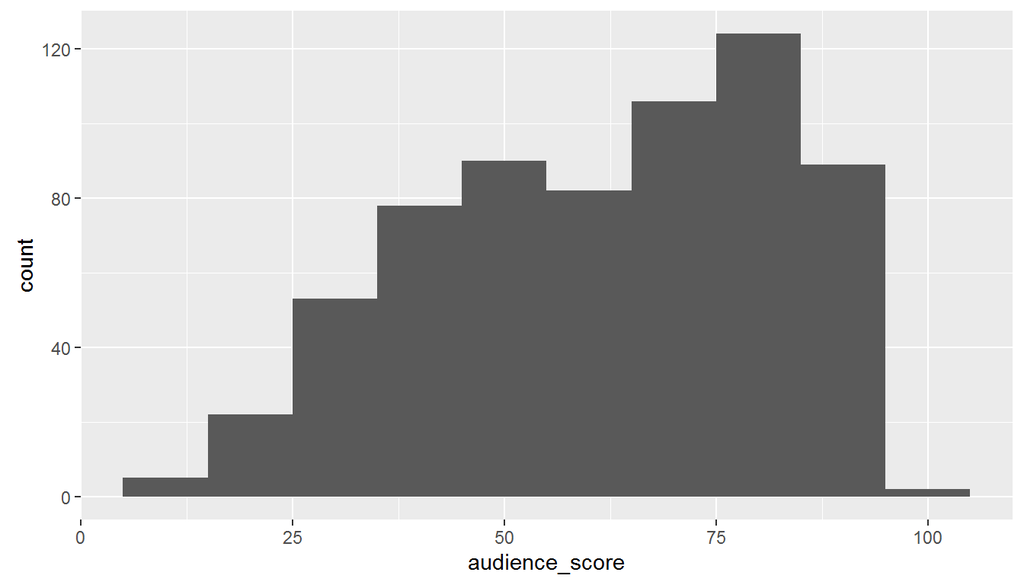

```r
audience_plot <- ggplot(movies1, aes(x = audience_score)) +
    geom_histogram(binwidth = 10)
audience_plot
```

The audience scores show a unimodal left-skewed distribution. As for the runtime variable:

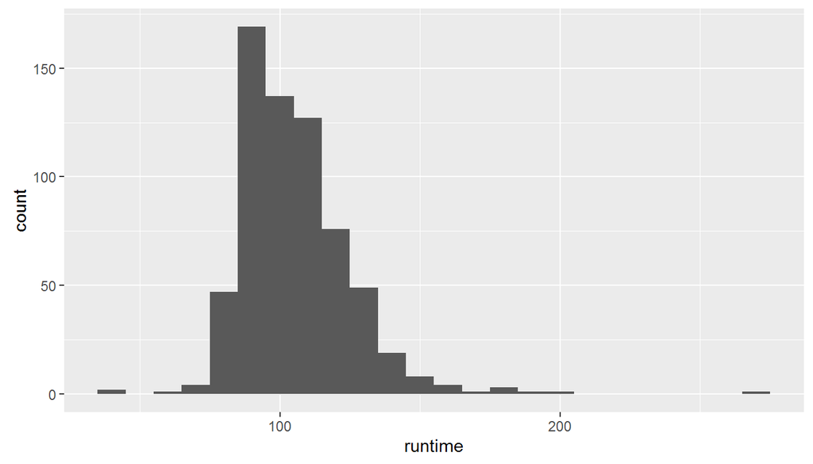

```r
runtime_plot <- ggplot(data = movies1, aes(x = runtime)) +
    geom_histogram(binwidth = 10)
runtime_plot
```

The distribution for the runtime variable in also unimodal with a slight right skew.

Next, a scatterplot is formed to visually analyze any apparent association between audience_score and movie runtimes.

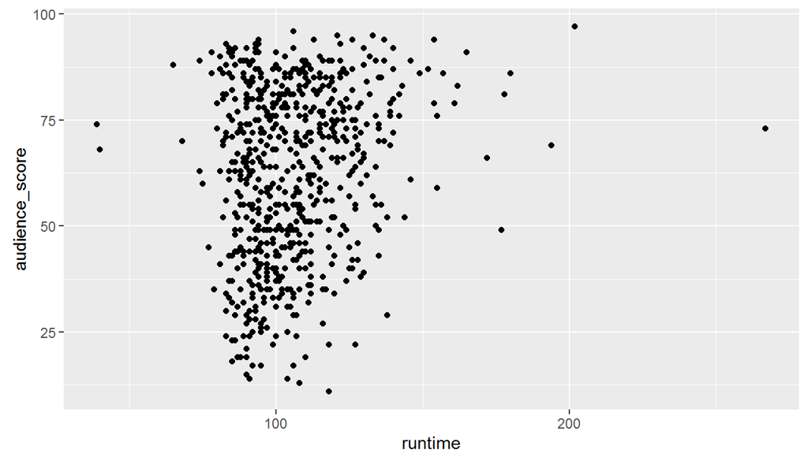

```r
aud_time_plot <- ggplot(data = movies1, aes(x = runtime, y = audience_score)) +
                    geom_point()
aud_time_plot
```

As evident in the scatterplot, majority of the movies are located between 90 to 140 minutes with a wide variability in their respective audience score. This indicates a weak association between the two variables. To formally determine this, a linear regression was performed.

```r
a <- lm(audience_score ~ runtime, data = movies1)
summary(a)
```

```
##
## Call:
## lm(formula = audience_score ~ runtime, data = movies1)
##
## Residuals:
##     Min      1Q  Median      3Q     Max
## -53.641 -15.626   3.008  17.080  34.950
##
## Coefficients:
##             Estimate Std. Error t value Pr(>|t|)
## (Intercept)  42.4203     4.3256   9.807  < 2e-16 ***
## runtime       0.1883     0.0402   4.684 3.43e-06 ***
## ---
## Signif. codes:  0 '***' 0.001 '**' 0.01 '*' 0.05 '.' 0.1 ' ' 1
##
## Residual standard error: 19.92 on 648 degrees of freedom
##   (1 observation deleted due to missingness)
## Multiple R-squared:  0.03275,    Adjusted R-squared:  0.03125
## F-statistic: 21.94 on 1 and 648 DF,  p-value: 3.431e-06
```

Basing on the results, the correlation between the movie runtimes and audience score is positive but not strong. With an R squared = 0.03275 (R = 0.18), only 3% of the variability of the audience_score can be explained by the movies’ runtimes. Still it is significant as indicated by the very low p-value (3.431e-06). The model for this association is:

audience_score = 42.4203 + (0.1883)runtime

Overlaying the model on the scatterplot shows:

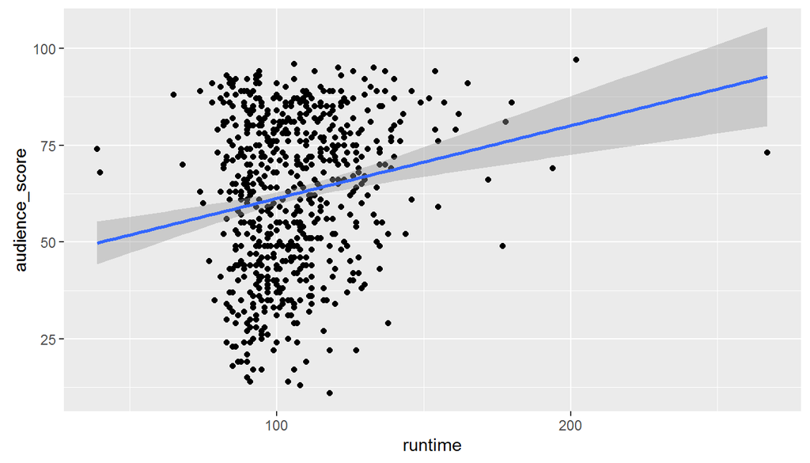

```r
aud_time_plot + geom_smooth(method = lm)
```

Overall, a movie’s runtime is not strong predictor for its popularity. Other aspects of the movies whether as individual or in combinations can provide better predictions for the movie popularity.

## Part 4: Modeling

In order to arrive at a linear model that provides the best possible prediction to a movie’s popularity, relevant variables should only be considered. Such variables should represent its potential contribution to the quality of the movie and therefore to the quality of the experience of the audience. The ability of the actors and actresses to effectively portray their respective character is tantamount to a good movie. Therefore, the variables best_actor_win and best_actress_win are included. Having an excellent director is also important for a great movie, so the variable best_dir_win is also included. The critics_score is also included since the scores are derived from designated or even professional movie critics and reviewers. The imdb_rating however is not included since it represents input from both audience and critics, therefore potentially providing colinearity with the critics_score and the audience_score, which is the response variable.

The rest of the variables are excluded since some either don’t provide relevant information for the movie’s popularity (e.g. genre, title_type, mpaa_rating, release dates, names) or provide parallel results from that of the included variables (e.g. critics_rating, audience_rating).

Therefore the response variable for the model is the audience_score while the predictor variables included are critics_score, best_actor_win, best_actress_win, and best_dir_win. A backwards R squared method was used since the intention is to arrive on a model with more reliable predictors. A full model was then formed.

```r
full_model <- lm(audience_score ~ critics_score +
                                   best_actor_win +
                                   best_actress_win +
                                   best_dir_win, data = movies1)
summary(full_model)
```

```
##
## Call:
## lm(formula = audience_score ~ critics_score + best_actor_win +
##     best_actress_win + best_dir_win, data = movies1)
##
## Residuals:
##     Min      1Q  Median      3Q     Max
## -37.259  -9.345   0.703  10.194  43.384
##
## Coefficients:
##                     Estimate Std. Error t value Pr(>|t|)
## (Intercept)         33.58358    1.29510  25.931   <2e-16 ***
## critics_score        0.50234    0.02009  25.000   <2e-16 ***
## best_actor_winyes   -0.71217    1.63509  -0.436    0.663
## best_actress_winyes -0.96452    1.82223  -0.529    0.597
## best_dir_winyes      0.12513    2.30833   0.054    0.957
## ---
## Signif. codes:  0 '***' 0.001 '**' 0.01 '*' 0.05 '.' 0.1 ' ' 1
##
## Residual standard error: 14.39 on 646 degrees of freedom
## Multiple R-squared:  0.4964, Adjusted R-squared:  0.4933
## F-statistic: 159.2 on 4 and 646 DF,  p-value: < 2.2e-16
```

With the R-squared method:

```r
m1 <- lm(audience_score ~ critics_score +
                                   best_actor_win +
                                   best_actress_win, data = movies1)
summary(m1)
```

```
##
## Call:
## lm(formula = audience_score ~ critics_score + best_actor_win +
##     best_actress_win, data = movies1)
##
## Residuals:
##     Min      1Q  Median      3Q     Max
## -37.268  -9.354   0.712  10.182  43.383
##
## Coefficients:
##                     Estimate Std. Error t value Pr(>|t|)
## (Intercept)         33.58201    1.29378  25.957   <2e-16 ***
## critics_score        0.50248    0.01991  25.232   <2e-16 ***
## best_actor_winyes   -0.70426    1.62732  -0.433    0.665
## best_actress_winyes -0.95819    1.81708  -0.527    0.598
## ---
## Signif. codes:  0 '***' 0.001 '**' 0.01 '*' 0.05 '.' 0.1 ' ' 1
##
## Residual standard error: 14.38 on 647 degrees of freedom
## Multiple R-squared:  0.4964, Adjusted R-squared:  0.4941
## F-statistic: 212.6 on 3 and 647 DF,  p-value: < 2.2e-16
```

```r
m2 <- lm(audience_score ~ critics_score +
                                   best_actor_win +
                                   best_dir_win, data = movies1)
summary(m2)
```

```
##
## Call:
## lm(formula = audience_score ~ critics_score + best_actor_win +
##     best_dir_win, data = movies1)
##
## Residuals:
##     Min      1Q  Median      3Q     Max
## -37.165  -9.628   0.665  10.268  43.448
##
## Coefficients:
##                   Estimate Std. Error t value Pr(>|t|)
## (Intercept)       33.52628    1.28985  25.992   <2e-16 ***
## critics_score      0.50185    0.02006  25.016   <2e-16 ***
## best_actor_winyes -0.82212    1.62094  -0.507    0.612
## best_dir_winyes    0.04684    2.30231   0.020    0.984
## ---
## Signif. codes:  0 '***' 0.001 '**' 0.01 '*' 0.05 '.' 0.1 ' ' 1
##
## Residual standard error: 14.39 on 647 degrees of freedom
## Multiple R-squared:  0.4962, Adjusted R-squared:  0.4939
## F-statistic: 212.4 on 3 and 647 DF,  p-value: < 2.2e-16
```

```r
m3 <- lm(audience_score ~ critics_score +
                                   best_actress_win +
                                   best_dir_win, data = movies1)
summary(m3)
```

```
##
## Call:
## lm(formula = audience_score ~ critics_score + best_actress_win +
##     best_dir_win, data = movies1)
##
## Residuals:
##     Min      1Q  Median      3Q     Max
## -37.170  -9.591   0.796  10.281  43.458
##
## Coefficients:
##                     Estimate Std. Error t value Pr(>|t|)
## (Intercept)         33.51210    1.28385  26.103   <2e-16 ***
## critics_score        0.50211    0.02007  25.012   <2e-16 ***
## best_actress_winyes -1.06535    1.80633  -0.590    0.556
## best_dir_winyes      0.03544    2.29769   0.015    0.988
## ---
## Signif. codes:  0 '***' 0.001 '**' 0.01 '*' 0.05 '.' 0.1 ' ' 1
##
## Residual standard error: 14.39 on 647 degrees of freedom
## Multiple R-squared:  0.4963, Adjusted R-squared:  0.4939
## F-statistic: 212.5 on 3 and 647 DF,  p-value: < 2.2e-16
```

```r
m4 <- lm(audience_score ~ best_actor_win +
                                   best_actress_win +
                                   best_dir_win, data = movies1)
summary(m4)
```

```
##
## Call:
## lm(formula = audience_score ~ best_actor_win + best_actress_win +
##     best_dir_win, data = movies1)
##
## Residuals:
##    Min     1Q Median     3Q    Max
## -51.05 -16.69   3.31  17.31  34.31
##
## Coefficients:
##                     Estimate Std. Error t value Pr(>|t|)
## (Intercept)          61.6904     0.9010  68.468   <2e-16 ***
## best_actor_winyes     0.3548     2.2909   0.155    0.877
## best_actress_winyes   1.1509     2.5512   0.451    0.652
## best_dir_winyes       7.4813     3.2089   2.331    0.020 *
## ---
## Signif. codes:  0 '***' 0.001 '**' 0.01 '*' 0.05 '.' 0.1 ' ' 1
##
## Residual standard error: 20.18 on 647 degrees of freedom
## Multiple R-squared:  0.009235,   Adjusted R-squared:  0.004641
## F-statistic:  2.01 on 3 and 647 DF,  p-value: 0.1113
```

The results from the R-squared method yielded the same results since all of the resulting adjusted R-squares are greater than 0.4933 (full model) except for the critics_score variable.

For diagnostics:

```r
final_mod <- lm(audience_score ~ critics_score, data = movies1)
summary(final_mod)
```

```
##
## Call:
## lm(formula = audience_score ~ critics_score, data = movies1)
##
## Residuals:
##     Min      1Q  Median      3Q     Max
## -37.043  -9.571   0.504  10.422  43.544
##
## Coefficients:
##               Estimate Std. Error t value Pr(>|t|)
## (Intercept)   33.43551    1.27561   26.21   <2e-16 ***
## critics_score  0.50144    0.01984   25.27   <2e-16 ***
## ---
## Signif. codes:  0 '***' 0.001 '**' 0.01 '*' 0.05 '.' 0.1 ' ' 1
##
## Residual standard error: 14.37 on 649 degrees of freedom
## Multiple R-squared:  0.496,  Adjusted R-squared:  0.4952
## F-statistic: 638.7 on 1 and 649 DF,  p-value: < 2.2e-16
```

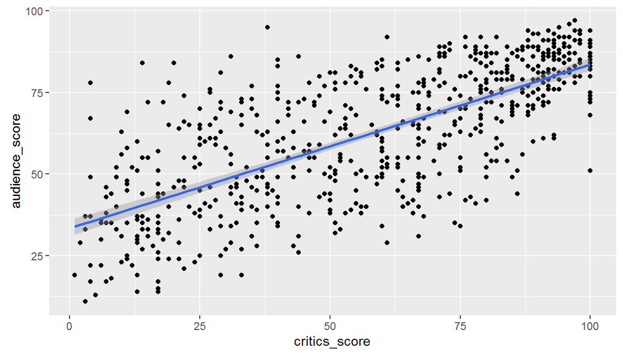

```r
ggplot(data = movies, aes(x = critics_score, y = audience_score)) +
    geom_point() +
    geom_smooth(method = lm)
```

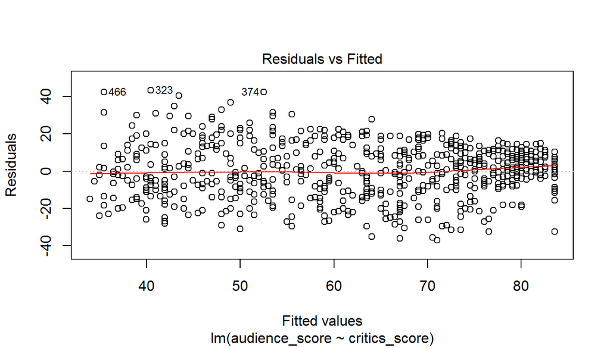

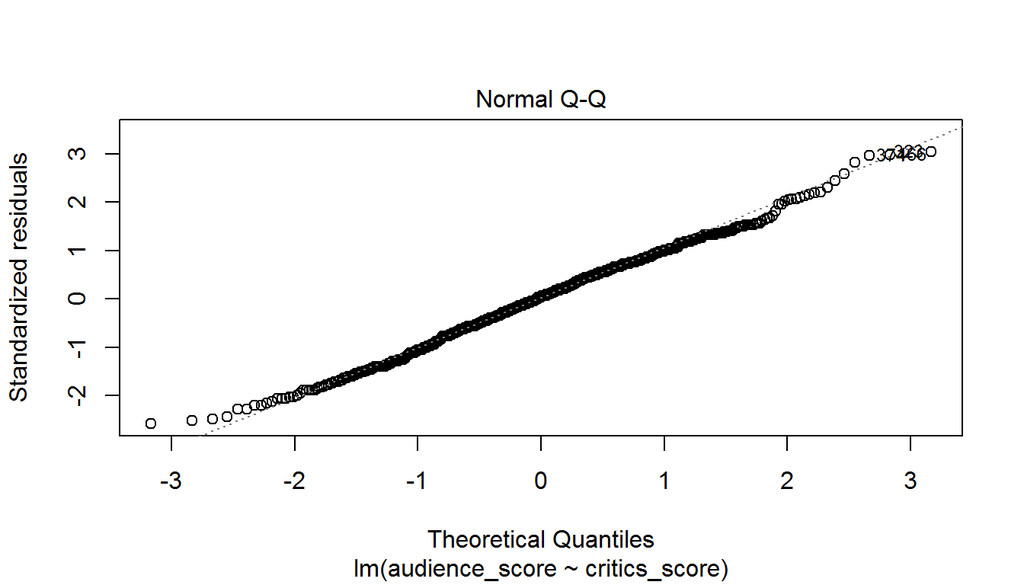

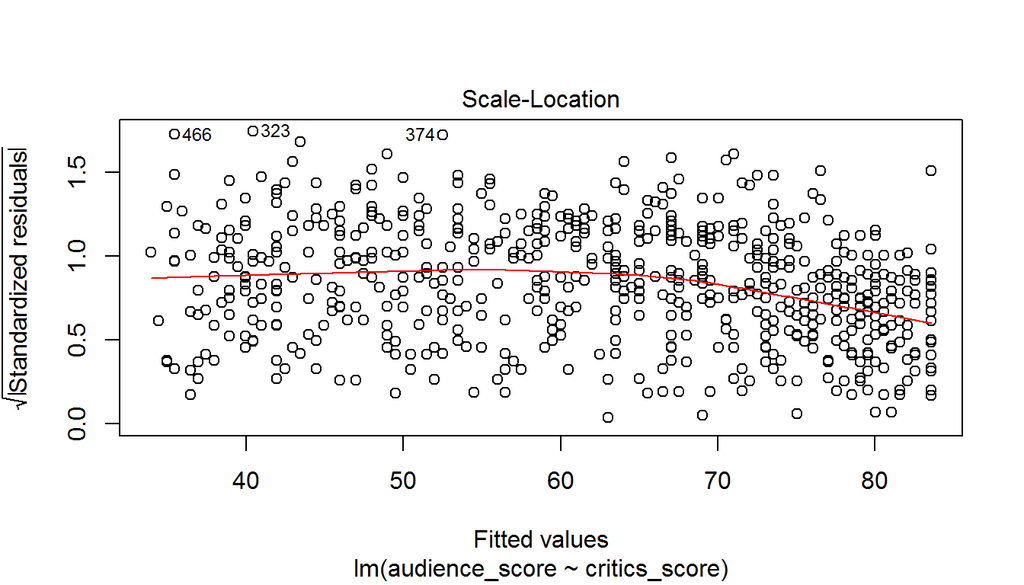

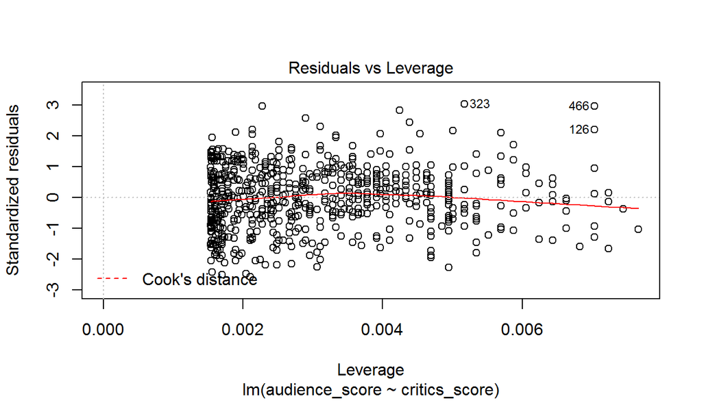

```r
plot(lm(audience_score ~ critics_score, data = movies1))
```

## Part 5: Prediction

```r
critic <- data.frame(critics_score = 56)
predict(final_mod, newdata = critic, interval = "prediction")
```

```
##        fit      lwr      upr
## 1 61.51601 33.28163 89.75039
```

The predicted audience score of 61.51601 is actually close to the actual audience score of 61. Also, we can 95% confident that the predicted value will fall between 33.28163 and 89.75039.

## Part 6: Conclusion

While most people base their decisions to watch a particular movie on other factors such as the actors and actresses involved, the director that orchestrated the movie, the premise of the movie’s storyline, and perhaps the quality of its promotional materials, data from this project supports that the Critics Score in Rotten Tomatoes can be used to predict the audience’ enjoyment of a particular movie and therefore the movie’s eventual popularity. This is understandable since such critics are more likely to be more adept in identifying details that could make a good movie.